# Step-by-step guide to the MO-Coxmos pipeline

## MB.sPLS-DRCOX

To enhance the versatility and performance of our survival analysis methods, we have developed full multiblock survival models by combining the sPLS-DRCOX methodology with the multiblock sPLS functions from the mixOmics R package. This allows a full integration for omic by selecting the components to reach the same objective.

In the creation of these methods, we utilized an heuristic variable selection approach along with the MixOmics algorithms for hyperparameter selection. The penalty is determined based on a vector of the number of variables to test. Users have the flexibility to specify a specific value for selecting a fixed number of variables. Alternatively, by setting the value to NULL, the heuristic process automatically selects the optimal number of variables.

Our method empowers users to define the minimum and maximum number of variables to consider, as well as the number of cutpoints to test between these limits. Through an iterative process, the algorithm identifies the optimal number of variables and further explores the performance of existing cutpoints compared to the selected optimal value.

This integration of sPLS-DRCOX and multiblock sPLS provides researchers with a powerful tool for conducting comprehensive multivariate survival analysis.

```r
cv.mb.splsdrcox_res <- cv.mb.splsdrcox(X = X_train, Y = Y_train,
                                       max.ncomp = 2, vector = NULL, #NULL - autodetection
                                       MIN_NVAR = 10, MAX_NVAR = 1000, n.cut_points = 10, EVAL_METHOD = "AUC",
                                       n_run = 2, k_folds = 4,
                                       x.center = x.center, x.scale = x.scale,
                                       remove_near_zero_variance = T, remove_zero_variance = F, toKeep.zv = NULL,
                                       remove_variance_at_fold_level = F,
                                       remove_non_significant_models = F, alpha = 0.05,
                                       w_AIC = 0, w_c.index = 0, w_AUC = 1, w_BRIER = 0, times = NULL, max_time_points = 15,
                                       MIN_AUC_INCREASE = 0.01, MIN_AUC = 0.8, MIN_COMP_TO_CHECK = 3,
                                       pred.attr = "mean", pred.method = "cenROC", fast_mode = F,
                                       MIN_EPV = 5, return_models = F, remove_non_significant = F, returnData = F,
                                       PARALLEL = F, verbose = F, seed = 123)
```

```
#> As we are working with a multiblock approach with 2 blocks, a maximum of 5 components could be use.
#> Training all possible models for MB.sPLS-DRCOX...
#> As we are working with a multiblock approach with 2 blocks, a maximum of 4 components could be use.
#> As we are working with a multiblock approach with 2 blocks, a maximum of 4 components could be use.
#> As we are working with a multiblock approach with 2 blocks, a maximum of 4 components could be use.
#> As we are working with a multiblock approach with 2 blocks, a maximum of 4 components could be use.
#> As we are working with a multiblock approach with 2 blocks, a maximum of 4 components could be use.
#> As we are working with a multiblock approach with 2 blocks, a maximum of 4 components could be use.
#> As we are working with a multiblock approach with 2 blocks, a maximum of 4 components could be use.
#> As we are working with a multiblock approach with 2 blocks, a maximum of 4 components could be use.
#> Creating sub-models for MB.sPLS-DRCOX...
#> Evaluating COX models (AIC and C-Index)...
#> Evaluating prediction acuracy with Brier Score... [BEST_MODE]
#> Evaluating prediction acuracy with cenROC algorithm... [BEST_MODE]
#> Best model obtained.
```

```r
cv.mb.splsdrcox_res #1.5min
```

```
#> The cross validation method used is cv.MB.sPLS-DRCOX.
#>
#> Best model is:
#>
#>   n.comps   n.var      AIC   c_index    BRIER       AUC     score
#> 2       2 326_369 259.2866 0.5570405 0.181629 0.4129071 0.7071068
```

After getting the cross-validation, the full model could be optain by passing the optimizal number of components and the list of the number of variables per omic.

```r
mb.splsdrcox_model <- mb.splsdrcox(X = X_train, Y = Y_train,
                                   n.comp = cv.mb.splsdrcox_res$opt.comp,
                                   vector = cv.mb.splsdrcox_res$opt.nvar,
                                   x.center = x.center, x.scale = x.scale,
                                   remove_near_zero_variance = T, remove_zero_variance = T, toKeep.zv = NULL,
                                   remove_non_significant = T, alpha = 0.05,
                                   MIN_AUC_INCREASE = 0.01,
                                   pred.method = "cenROC", max.iter = 200,
                                   times = NULL, max_time_points = 15,
                                   MIN_EPV = 5, returnData = T, verbose = F)
```

```
#> As we are working with a multiblock approach with 2 blocks, a maximum of 5 components could be use.
```

```r
mb.splsdrcox_model
```

```
#> The method used is MB.sPLS-DRCOX.
#>
#> A total of 3 variables have been removed due to non-significance filter inside cox model.
#>
#> Survival model:
#>                      coef exp(coef)     se(coef)    robust se        z
#> comp_2_mirna 3.711288e-07         1 3.431286e-07 3.145653e-07 1.179815
#>               Pr(>|z|)
#> comp_2_mirna 0.2380739
```

## MB.sPLS-DACOX

We also have extended our methodological repertoire with the development of MB.sPLS-DACOX. Building upon the foundation of sPLS-DACOX, this novel approach incorporates the powerful MultiBlock functions from the MixOmics R package, further enhancing its capabilities and performance.

```r
# run cv.splsdrcox
cv.mb.splsdacox_res <- cv.mb.splsdacox(X = X_train, Y = Y_train,
                                       max.ncomp = 2, vector = NULL, #NULL - autodetection
                                       n_run = 2, k_folds = 4,
                                       x.center = x.center, x.scale = x.scale,
                                       remove_near_zero_variance = T, remove_zero_variance = F, toKeep.zv = NULL,
                                       remove_variance_at_fold_level = F,
                                       remove_non_significant_models = F, alpha = 0.05,
                                       w_AIC = 0, w_c.index = 0, w_AUC = 1, w_BRIER = 0, times = NULL, max_time_points = 15,
                                       MIN_AUC_INCREASE = 0.01, MIN_AUC = 0.8, MIN_COMP_TO_CHECK = 3,
                                       pred.attr = "mean", pred.method = "cenROC", fast_mode = F,
                                       MIN_EPV = 5, return_models = F, remove_non_significant = F, returnData = F,
                                       PARALLEL = F, verbose = F, seed = 123)
```

```
#> As we are working with a multiblock approach with 2 blocks, a maximum of 5 components could be use.
#> Training all possible models for MB.sPLS-DACOX...
#> As we are working with a multiblock approach with 2 blocks, a maximum of 4 components could be use.
#> As we are working with a multiblock approach with 2 blocks, a maximum of 4 components could be use.
#> As we are working with a multiblock approach with 2 blocks, a maximum of 4 components could be use.
#> As we are working with a multiblock approach with 2 blocks, a maximum of 4 components could be use.
#> As we are working with a multiblock approach with 2 blocks, a maximum of 4 components could be use.
#> As we are working with a multiblock approach with 2 blocks, a maximum of 4 components could be use.
#> As we are working with a multiblock approach with 2 blocks, a maximum of 4 components could be use.
#> As we are working with a multiblock approach with 2 blocks, a maximum of 4 components could be use.
#> Creating sub-models for MB.sPLS-DACOX...
#> Evaluating COX models (AIC and C-Index)...
#> Evaluating prediction acuracy with Brier Score... [BEST_MODE]
#> Evaluating prediction acuracy with cenROC algorithm... [BEST_MODE]
#> Best model obtained.
```

```r
cv.mb.splsdacox_res #2min
```

```
#> The cross validation method used is cv.MB.sPLS-DACOX.
#>
#> Best model is:
#>
#>   n.comps  n.var      AIC   c_index     BRIER       AUC     score
#> 2       2 326_10 258.5164 0.5751782 0.2151131 0.3857964 0.7071068
```

After getting the cross-validation, the full model could be optain by passing the optimizal number of components and the list of the number of variables per omic.

```r
mb.splsdacox_model <- mb.splsdacox(X = X_train, Y = Y_train,
                                   n.comp = cv.mb.splsdacox_res$opt.comp,
                                   vector = cv.mb.splsdacox_res$opt.nvar,
                                   x.center = x.center, x.scale = x.scale,
                                   remove_near_zero_variance = T, remove_zero_variance = T, toKeep.zv = NULL,
                                   remove_non_significant = T, alpha = 0.05,
                                   MIN_AUC_INCREASE = 0.01,
                                   pred.method = "cenROC", max.iter = 200,
                                   times = NULL, max_time_points = 15,
                                   MIN_EPV = 5, returnData = T, verbose = F)
```

```
#> As we are working with a multiblock approach with 2 blocks, a maximum of 5 components could be use.
```

```r
mb.splsdacox_model
```

```
#> The method used is MB.sPLS-DACOX.
#>
#> A total of 3 variables have been removed due to non-significance filter inside cox model.
#>
#> Survival model:
#>                        coef exp(coef)   se(coef)  robust se        z  Pr(>|z|)
#> comp_2_proteomic 0.08603784  1.089848 0.07477169 0.07753615 1.109648 0.2671507
```

# Comparing multiple survival models

Next, we will analyze the results obtained from the multiple models to see which one obtains the best predictions based on our data. To do this, we will use the test set that has not been used for the training of any model.

## Comparing for multiple evaluators at the same time.

Initially, we will compare the area under the curve (AUC) for each of the methods according to the evaluator we want. The function is developed to simultaneously evaluate multiple evaluators. However, we will continue working with a single evaluator. In this case “cenROC”. On the other hand, we must provide a list of the different models as well as the X and Y test set we want to evaluate.

When evaluating survival model results, we must indicate at which temporal points we want to perform the evaluation. As we already specified a NULL value for the “times” variable in the cross-validation, we are going to let the algorithm to compute them again.

```r
lst_models <- list("SB.sPLS-ICOX" = sb.splsicox_model,
                   "iSB.sPLS-ICOX" = isb.splsicox_model,
                   "SB.sPLS-DRCOX" = sb.splsdrcox_model,
                   "iSB.sPLS-DRCOX" = isb.splsdrcox_model,
                   "MB.sPLS-DRCOX" = mb.splsdrcox_model,
                   "MB.sPLS-DACOX" = mb.splsdacox_model)

eval_results <- eval_Coxmos_models(lst_models = lst_models,
                                  X_test = X_test, Y_test = Y_test,
                                  pred.method = "cenROC",
                                  pred.attr = "mean",
                                  times = NULL, max_time_points = 15,
                                  PARALLEL = F)
```

In case you prefer to test multiple AUC evaluators, a list of them could be proportionate by using the library “purrr”.

```r
lst_evaluators <- c(cenROC = "cenROC",
                    risksetROC = "risksetROC")

eval_results <- purrr::map(lst_evaluators, ~eval_Coxmos_models(lst_models = lst_models,
                                                              X_test = X_test, Y_test = Y_test,
                                                              pred.method = .,
                                                              pred.attr = "mean",
                                                              times = seq(1,4,0.5),
                                                              max_time_points = 15,
                                                              PARALLEL = F))
```

We can print the results obtained in the console where we can see, for each of the selected methods, the training time and the time it took to be evaluated, as well as their AIC, C-Index and AUC metrics and at which time points it was evaluated.

```r
eval_results
```

[output not shown]

## Plot comparison

However, we can also obtain graphical results where we can compare each method over time, as well as their average scores using the function “plot_evaluation” or “plot_evaluation.list” if multiple evaluators have been tested. The user could choose to plot the AUC for time prediction points or Brier Score. In case of use Brier Score, instead of uses the Integrative Brier Score for the boxplots, the mean or median is used (plot_evaluation parameter).

```r
lst_eval_results <- plot_evaluation(eval_results, evaluation = "AUC")
lst_eval_results_brier <- plot_evaluation(eval_results, evaluation = "Brier")
```

After performing the cross-validation, we obtain a list in R that contains two new lists. The first of these refers to the evaluation over time for each of the methods used, as well as a variant where the average value of each of them is shown. On the other hand, we can compare the mean results of each method using: T-test, Wilcoxon-test, anova or Kruskal-Wallis.

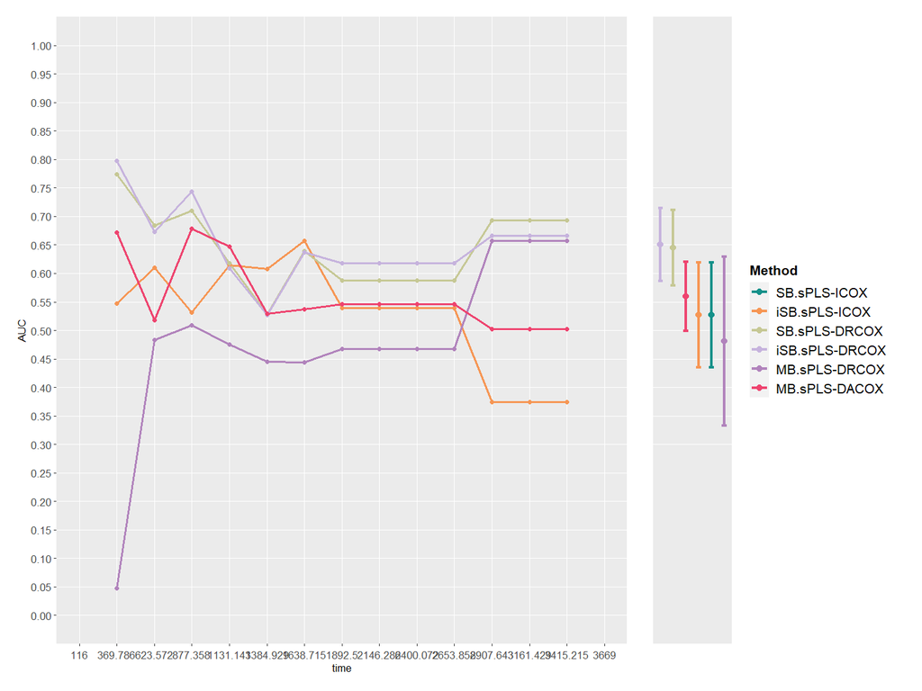

```r
lst_eval_results$lst_plots$lineplot.mean
```

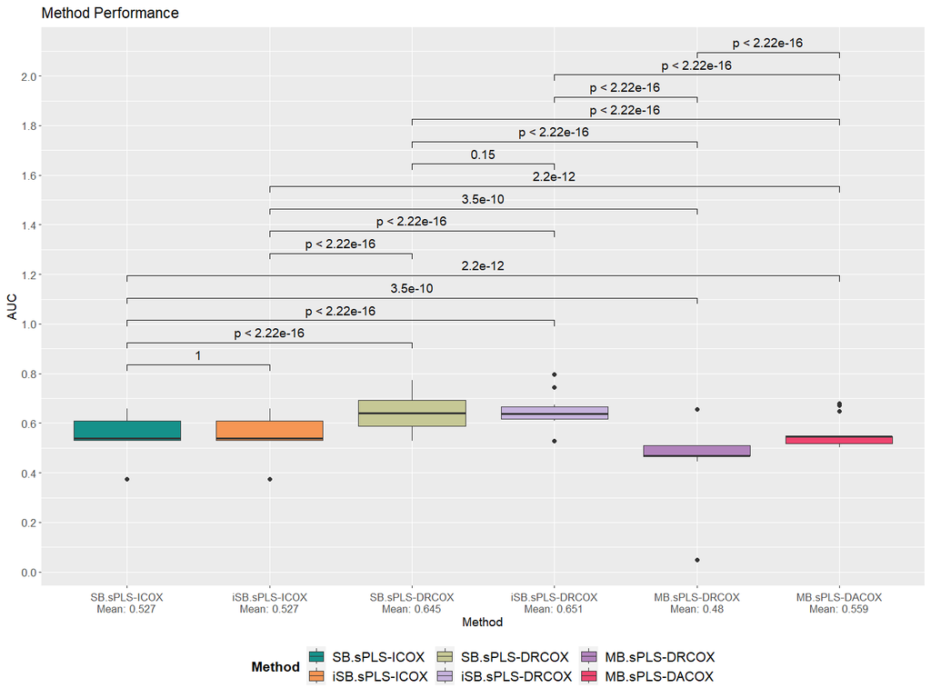

```r
lst_eval_results$lst_plot_comparisons$t.test
```

```r
# lst_eval_results$cenROC$lst_plots$lineplot.mean
# lst_eval_results$cenROC$lst_plot_comparisons$t.test
```

## Computing time comparison (we use the cross validation models)

Another possible comparison is related to the computation times for cross-validation, model creation, and evaluation. In this case, cross-validations and methods are loaded.

```r
lst_models_time <- list(cv.sb.splsicox_res,
                        sb.splsicox_model,
                        isb.splsicox_model,
                        cv.sb.splsdrcox_res,
                        sb.splsdrcox_model,
                        isb.splsdrcox_model,
                        cv.mb.splsdrcox_res,
                        mb.splsdrcox_model,
                        cv.mb.splsdrcox_res,
                        mb.splsdacox_model,
                        eval_results)
```

```r
ggp_time <- plot_time.list(lst_models_time)
```

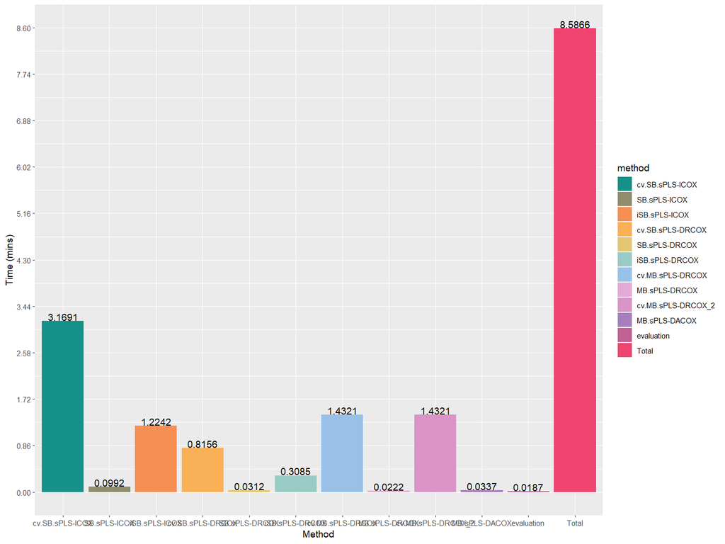

```r
ggp_time
```

# Individual interpretations of the results

## Forest plots

A forest plot can be obtained as the first graph using the survminer R package. However, the function has been restructured to allow for simultaneous launch of an Coxmos class model or a list of Coxmos models using the `plot_forest()` or `plot_forest.list()` function.

```r
lst_forest_plot <- plot_forest.list(lst_models)
```

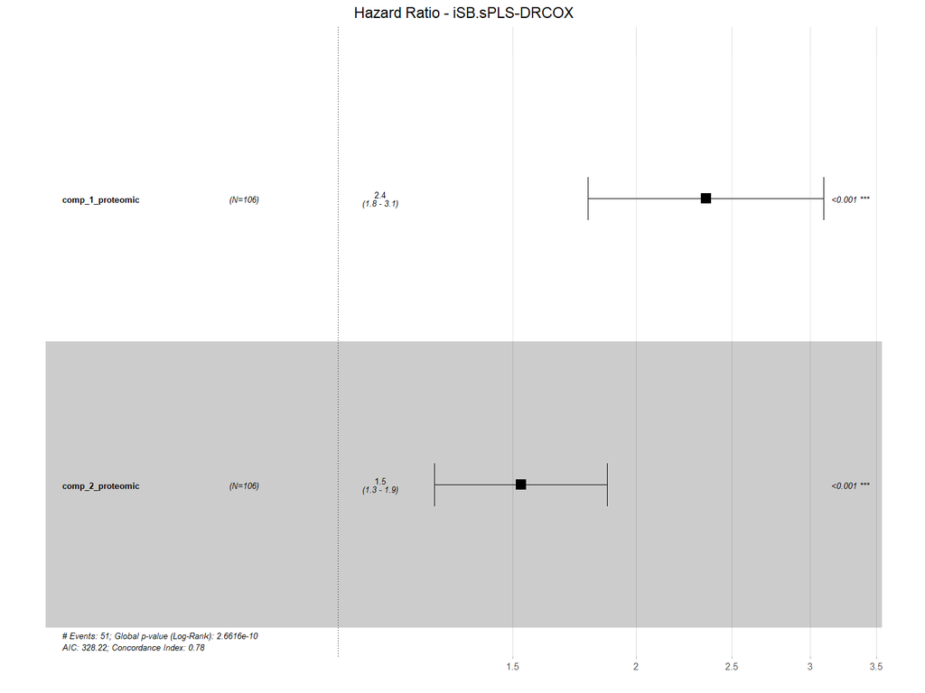

```r
lst_forest_plot$`iSB.sPLS-DRCOX`
```

## PH Assumption

The following graph is related to one of the assumptions of the Cox models, called proportional hazard.

In a Cox proportional hazards model, the proportional hazards assumption states that the hazard ratio (the risk of experiencing the event of interest) is constant over time for a given set of predictor variables. This means that the effect of the predictors on the hazard ratio does not change over time. This assumption is important because it allows for the interpretation of the model’s coefficients as measures of the effect of the predictors on the hazard ratio. Violations of the proportional hazards assumption can occur if the effect of the predictors on the hazard ratio changes over time or if there is an interaction between the predictors and time. In these cases, the coefficients of the model may not accurately reflect the effect of the predictors on the hazard ratio and the results of the model may not be reliable.

In this way, to visualize and check if the assumption is violated, the function `plot_proportionalHazard.list()` or `plot_proportionalHazard()` can be called, depending on whether a list of models or a specific model is to be evaluated.

```r
lst_ph_ggplot <- plot_proportionalHazard.list(lst_models)
```

Variables or components with a significant P-Value indicate that the assumption is being violated.

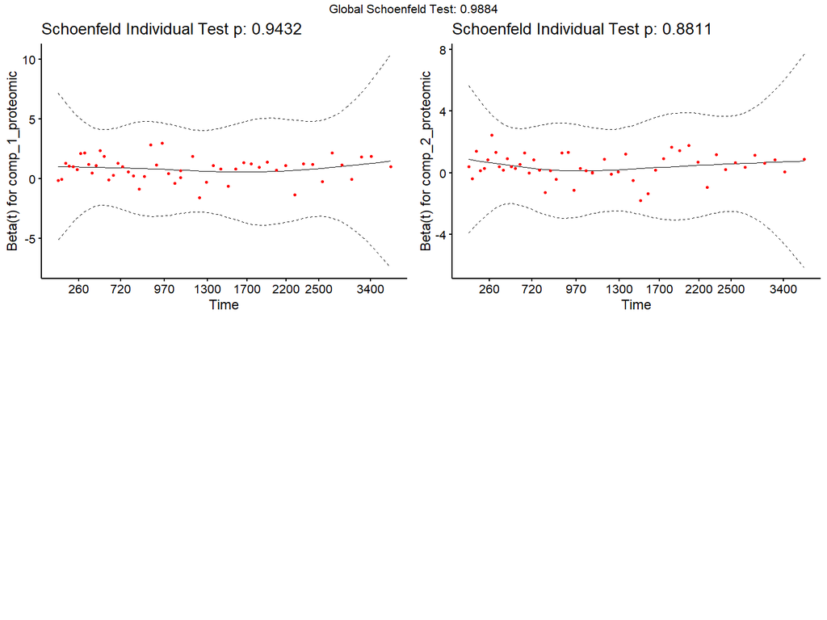

```r
lst_ph_ggplot$`iSB.sPLS-DRCOX`
```

## Density plots

Another type of graph implemented for all models, whether they belong to the classical branch or to PLS-based models, is the visualization of observations by event according to the values predicted by the Cox models.

The R package “coxph” allows for several types of predictions to be made on a Cox model that we use in our function, which are:

- Linear predictors “lp”: are the expected values of the response variable (in this case, time until the event of interest) for each observation, based on the Cox model. These values can be calculated from the mean of the predictor variable values and the constant term of the model.
- Risk of experiencing an event “risk”: is a measure of the probability that an event will occur for each observation, based on the Cox model. The risk value can be calculated from the predictor values and the constant term of the model.
- Number of events expected to be experienced over time with these specific individual characteristics “expected”: are the expected number of events that would occur for each observation, based on the Cox model and a specified period of time.
- Terms: are the variables included in the Cox model.
- Survival probability “survival”: is the probability that an individual will not experience the event of interest during a specified period of time, based on the Cox model. The survival probability can be calculated from the predictor values and the constant term of the model.

According to the predicted value, we can classify the observations along their possible values and see their distribution for each of the different models.

```r
density.plots.lp <- plot_cox.event.list(lst_models, type = "lp")
```

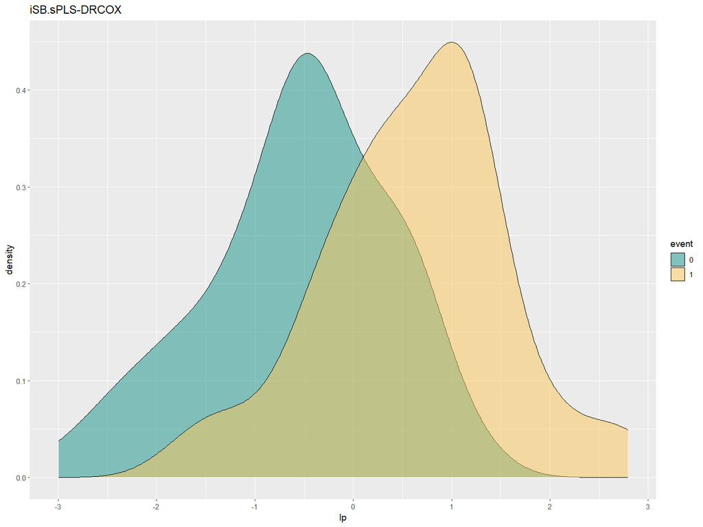

```r
density.plots.lp$`iSB.sPLS-DRCOX`$plot.density
```

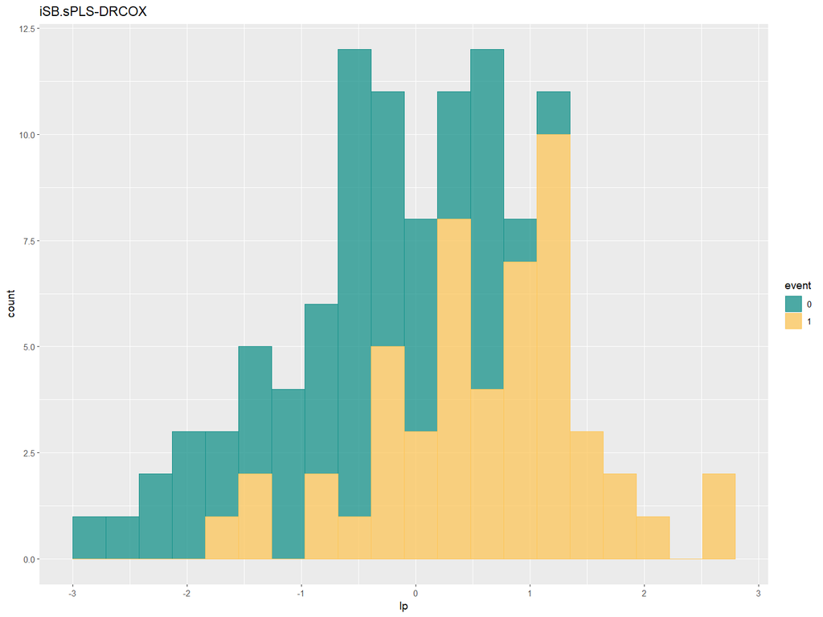

```r
density.plots.lp$`iSB.sPLS-DRCOX`$plot.histogram
```

## Studying PLS model

For those models based on PLS components, the PLS could be studied in terms of loadings/scores. In order to get the plots, the function `plot_PLS_Coxmos()` has been developed where the user could specify to see “scores”, “loadings” or a “biplot” for a couple of latent variables. By default, if no factor is given, samples are grouped by event.

```r
ggp_scores <- plot_PLS_Coxmos(model = lst_models$`iSB.sPLS-DRCOX`,
                             comp = c(1,2), mode = "scores")
```

```
#> The model has only 1 component
```

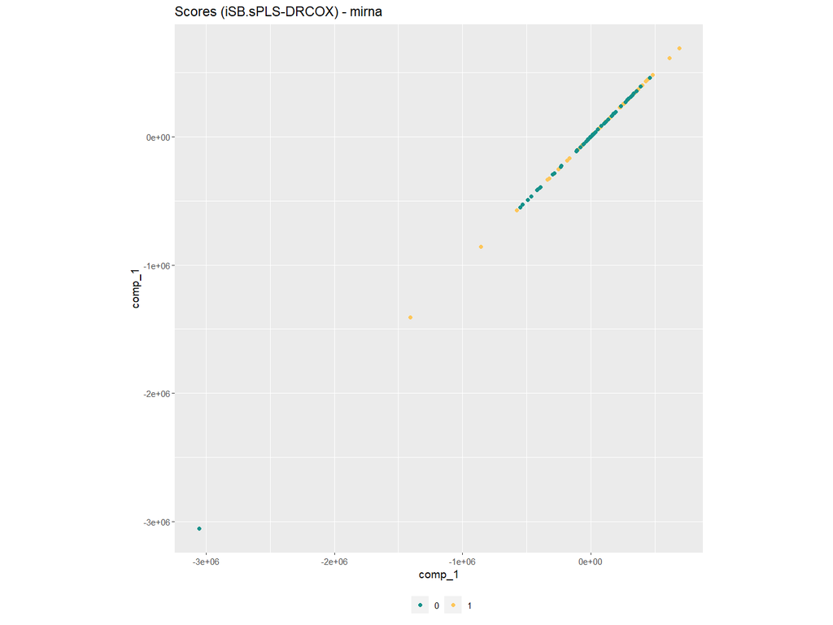

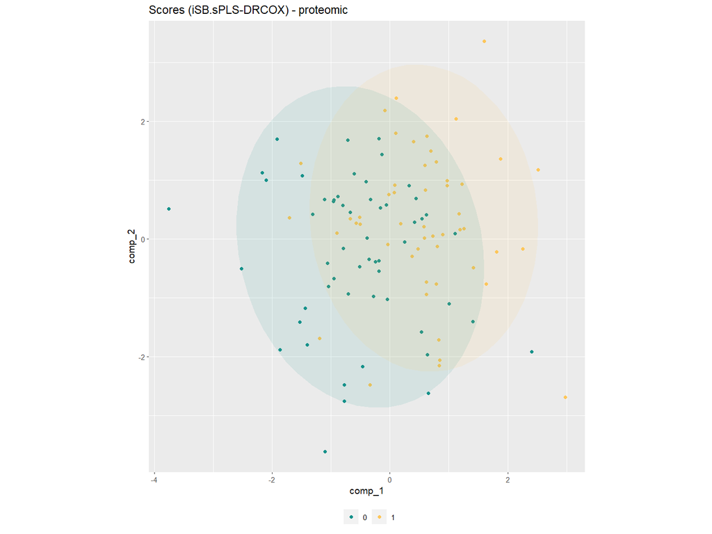

```r
ggp_scores$plot_block
```

```r
ggp_loadings <- plot_PLS_Coxmos(model = lst_models$`iSB.sPLS-DRCOX`,
                               comp = c(1,2), mode = "loadings",
                               top = 10) #length from 0,0
```

```
#> The model has only 1 component
```

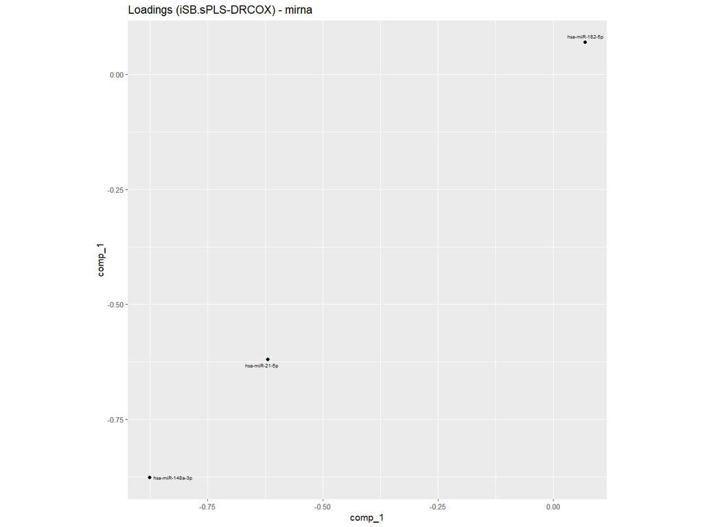

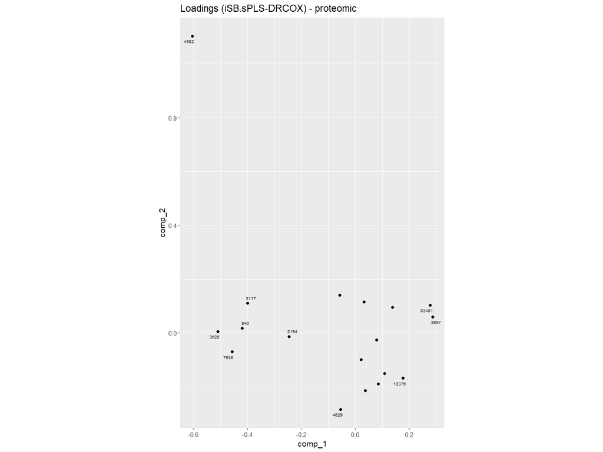

```r
ggp_loadings$plot_block
```

```r
ggp_biplot <- plot_PLS_Coxmos(model = lst_models$`iSB.sPLS-DRCOX`,
                             comp = c(1,2), mode = "biplot",
                             top = 15,
                             only_top = T)
```

```
#> The model has only 1 component
```

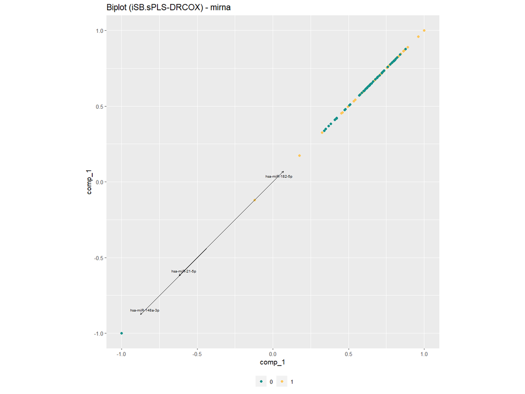

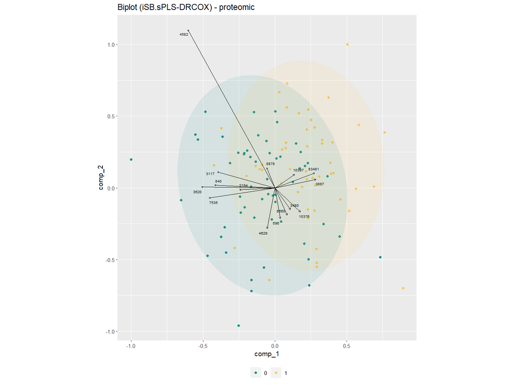

```r
ggp_biplot$plot_block
```

# Understanding the results in terms of the original variables (PLS models)

When a PLS-COX model is computed, the final survival model is based on the PLS latent variables. Although those new variables can explain the survival, in order to understand the disease, new coefficients could be computed in terms of the original variables.

Coxmos is able to transfer the component beta coefficient to original variables by decomposing the coefficients by using the weight of the variables in that latent variables.

## Understanding the relative contribution per variable/component

However, before studying the original variables, if a PLS model is computed. Coxmos also proportionates plots to see how many % of AUC is computed per each component in order to see which components or latent variables are more related to the observation survival.

The % of AUC explanation per component could be calculated for TRAIN or TEST data. Train data was used to compute the best model, so the sum of variables/components will generate a better LP (linear predictor) performance. However, when test data is used, could happen that a specific variable or a component could be a better predictor than the full model.

```r
variable_auc_results <- eval_Coxmos_model_per_variable(model = lst_models$`iSB.sPLS-DRCOX`,
                                                      X_test = lst_models$`iSB.sPLS-DRCOX`$X_input,
                                                      Y_test = lst_models$`iSB.sPLS-DRCOX`$Y_input,
                                                      pred.method = "cenROC", pred.attr = "mean",
                                                      times = NULL, max_time_points = 15,
                                                      PARALLEL = FALSE)

variable_auc_plot_train <- plot_evaluation(variable_auc_results, evaluation = "AUC")
```

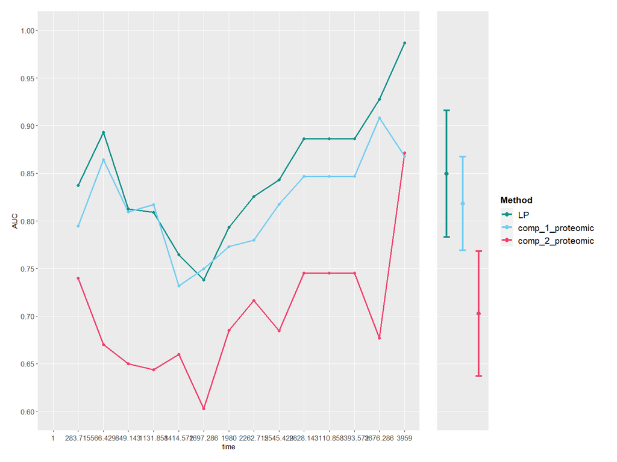

```r
variable_auc_plot_train$lst_plots$lineplot.mean
```

The plot shows the AUC for the full model (called LP), and then, the AUC per each variable (for classical methods) or components (for PLS methods).

## Psudobeta

In order to improve the interpretability of a PLS model, a subset of the most influential variables can be selected. In this example, the top 20 variables are chosen. Additionally, non-significant PLS components are excluded by setting the “onlySig” parameter to “TRUE”.

```r
ggp.simulated_beta <- plot_pseudobeta.list(lst_models = lst_models,
                                           error.bar = T, onlySig = T, alpha = 0.05,
                                           zero.rm = T, auto.limits = T, top = 20,
                                           show_percentage = T, size_percentage = 2, verbose = F)
```

The iSB.sPLS-DRCOX model was computed using a total of 2 components. Although these components were classified as dangerous for the observations (based on coefficients greater than one), certain variables within the components may still have a protective effect, depending on their individual weights.

The following plot illustrates the pseudo-beta coefficient for the original variables in the iSB.sPLS-DRCOX model. As only the top 20 variables are shown, in some case a percentage of the total linear predictor total value could be shown. To view the complete model, all variables would need to be included in the plot by assigning the value NULL to the “top” parameter.

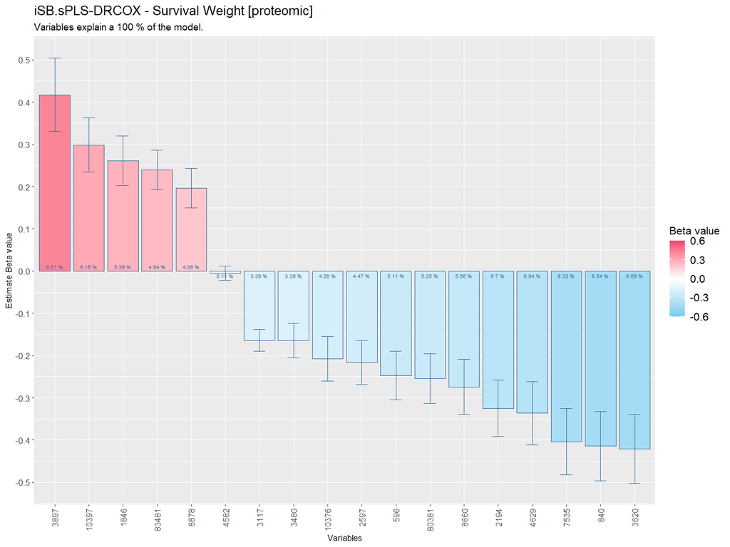

```r
ggp.simulated_beta$`iSB.sPLS-DRCOX`$plot
```

## Kaplan-Meier

For a more intuitive understanding of the model, the user can also employ the `getAutoKM.list()` or `getAutoKM()` functions to generate Kaplan-Meier curves. These functions allow the user to view the KM curve for the entire model, a specific component of a PLS model, or for individual variables.

### Full model

To run the full Kaplan-Meier model, the “type” parameter must be set to “LP” (linear predictors). This means that the linear predictor value for each patient will be used to divide the groups (in this case, the score value multiplied by the Cox coefficient). The “surv_cutpoint” function from the R package “survminer” is used to determine the optimal cut-point. Other parameters are not used in this specific method.

```r
LST_KM_RES_LP <- getAutoKM.list(type = "LP",
                                lst_models = lst_models,
                                comp = 1:4,
                                top = 10,
                                ori_data = T,
                                BREAKTIME = NULL,
                                only_sig = T, alpha = 0.05)
```

As a result, the Kaplan-Meier curve could be plotted.

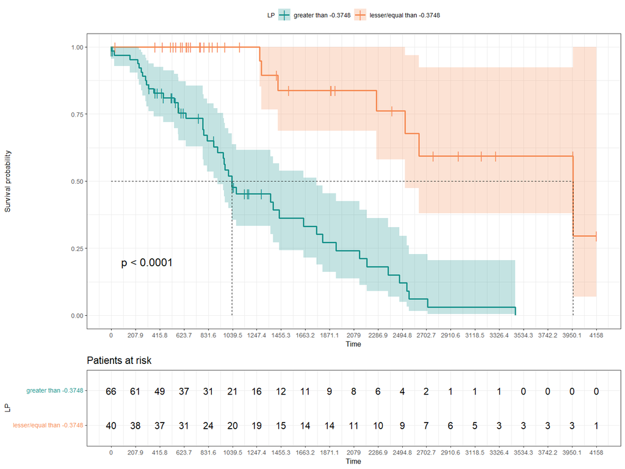

```r
LST_KM_RES_LP$`iSB.sPLS-DRCOX`$LST_PLOTS$LP
```

After generating a Kaplan-Meier curve for the model, the cutoff value, which is used to divide the observations into two groups, can be used to evaluate how the test data is classified. The vector of cutoffs for multiple models, when `getAutoKM.list()` is applied, can be retrieved by using the function `getCutoffAutoKM.list()` and passing the output of `getAutoKM.list()` as a parameter.

Once the vector is obtained, the function `getTestKM.list()` or `getTestKM()` can be run with the list of models, the X test data, Y test data, the list of cutoffs or a single value, and the desired number of breaks for the new Kaplan-Meier plot.

A log-rank test will be displayed to determine if the chosen cutoff is an effective way to split the data into groups with higher and lower risk.

```r
lst_cutoff <- getCutoffAutoKM.list(LST_KM_RES_LP)

LST_KM_TEST_LP <- getTestKM.list(lst_models = lst_models,
                                 X_test = X_test, Y_test = Y_test,
                                 type = "LP",
                                 BREAKTIME = NULL, n.breaks = 20,
                                 lst_cutoff = lst_cutoff)
```

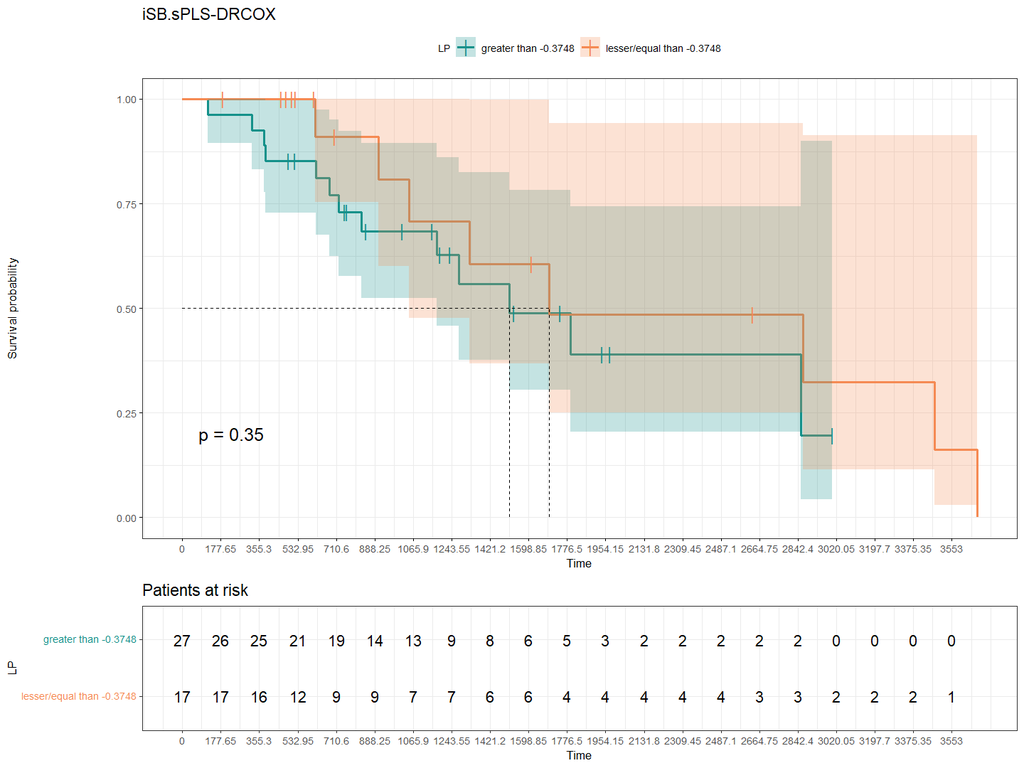

```r
LST_KM_TEST_LP$`iSB.sPLS-DRCOX`
```

### Components

To generate a Kaplan-Meier curve for a specific component, the “type” parameter must be set to “COMP” (component). This means that the linear predictor is computed using only one component at a time to split the groups. In this case, the “comp” parameter can be used to specify which component should be computed (if multiple components, each one will be computed separately).

```r
LST_KM_RES_COMP <- getAutoKM.list(type = "COMP",
                                  lst_models = lst_models,
                                  comp = 1:4,
                                  top = 10,
                                  ori_data = T,
                                  BREAKTIME = NULL,
                                  only_sig = T, alpha = 0.05)
```

```
#> None of the variables have a significant log-rank test value. Survival function, Hazard Curve, and Cumulative Hazard plots will be returned.
#> None of the variables have a significant log-rank test value. Survival function, Hazard Curve, and Cumulative Hazard plots will be returned.
```

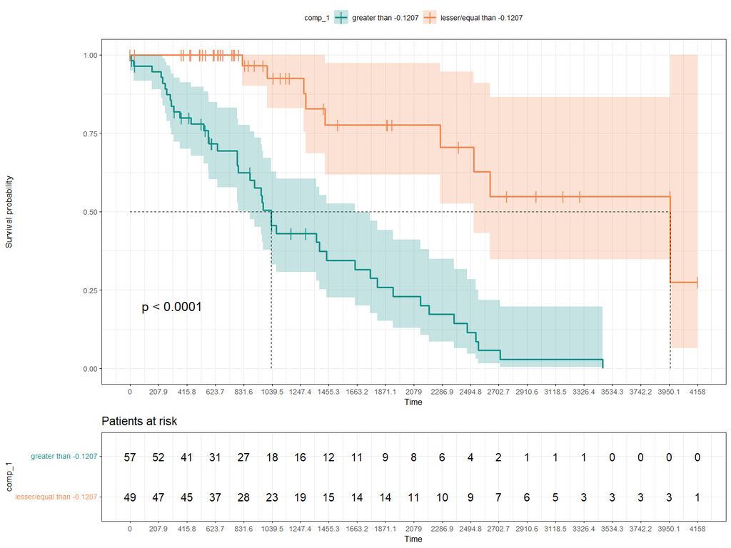

```r
LST_KM_RES_COMP$`iSB.sPLS-DRCOX`$LST_PLOTS$proteomic$comp_1
```

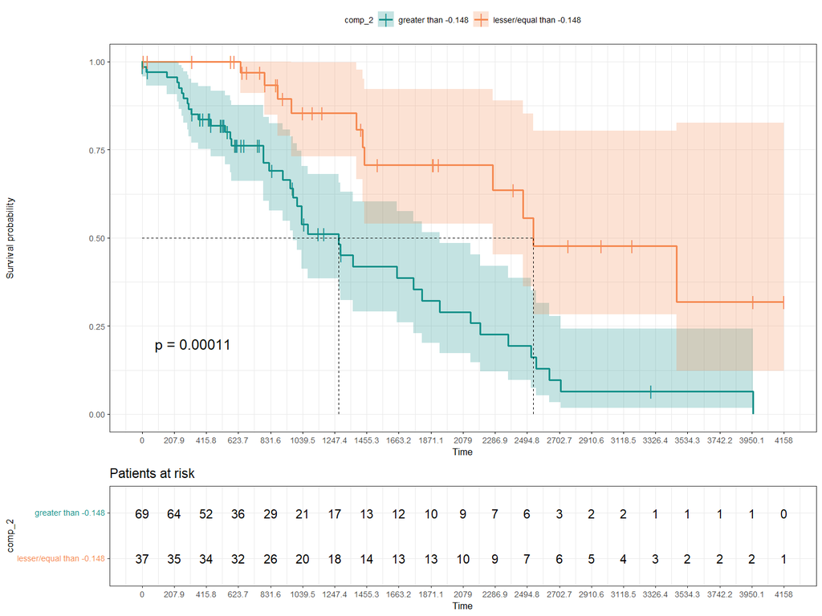

```r
LST_KM_RES_COMP$`iSB.sPLS-DRCOX`$LST_PLOTS$proteomic$comp_2
```

```r
lst_cutoff <- getCutoffAutoKM.list(LST_KM_RES_COMP)

LST_KM_TEST_COMP <- getTestKM.list(lst_models = lst_models,
                                   X_test = X_test, Y_test = Y_test,
                                   type = "COMP",
                                   BREAKTIME = NULL, n.breaks = 20,
                                   lst_cutoff = lst_cutoff)
```

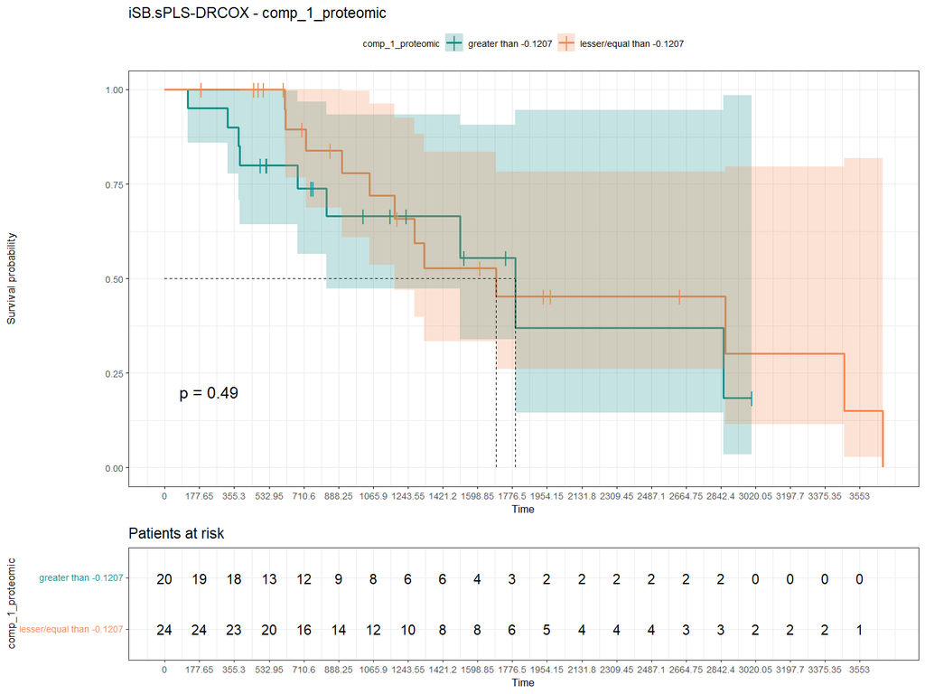

```r
LST_KM_TEST_COMP$`iSB.sPLS-DRCOX`$comp_1_proteomic
```

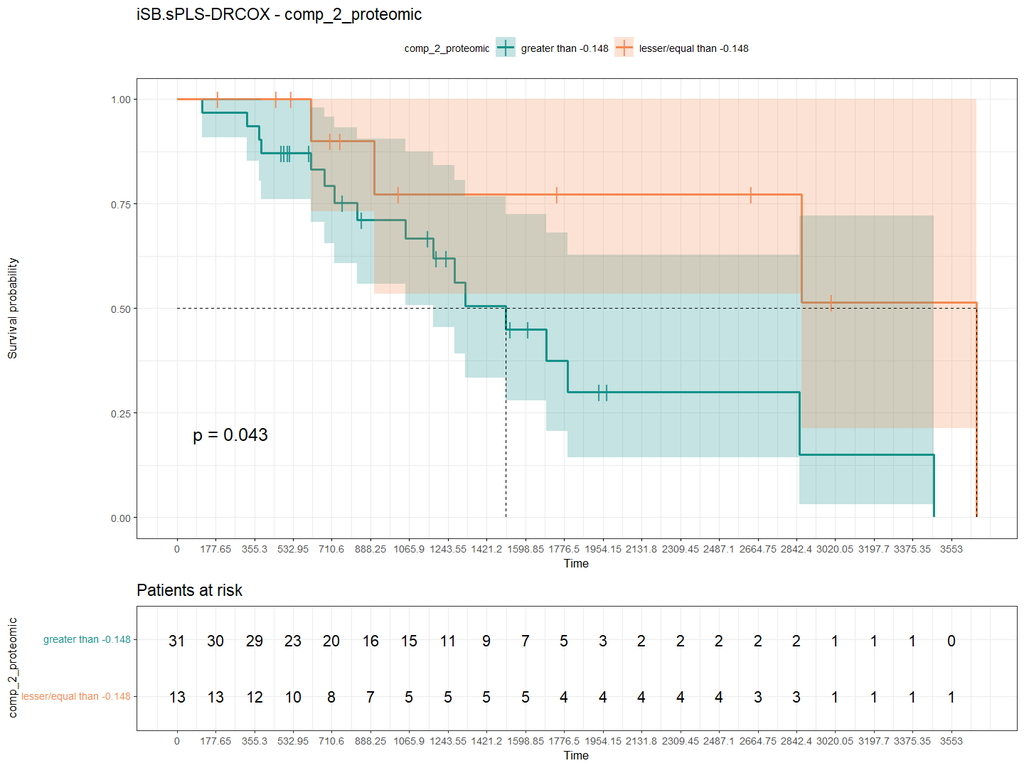

```r
LST_KM_TEST_COMP$`iSB.sPLS-DRCOX`$comp_2_proteomic
```

### Original variables

To generate a Kaplan-Meier curve for original variables, the “type” parameter must be set to “VAR” (variable). In this case, the “ori_data” parameter can be used to determine whether the original or normalized values of the variables should be used.

Additionally, the “top” parameter can be used to plot a specific number of variables, sorted by P-Value (Log-Rank test). The best cutpoint is determined by the “surv_cutpoint” function. Both qualitative and quantitative variables are supported.

```r
LST_KM_RES_VAR <- getAutoKM.list(type = "VAR",
                                 lst_models = lst_models,
                                 comp = 1:4,
                                 top = 10,
                                 ori_data = T,
                                 BREAKTIME = NULL,
                                 only_sig = T, alpha = 0.05)
```

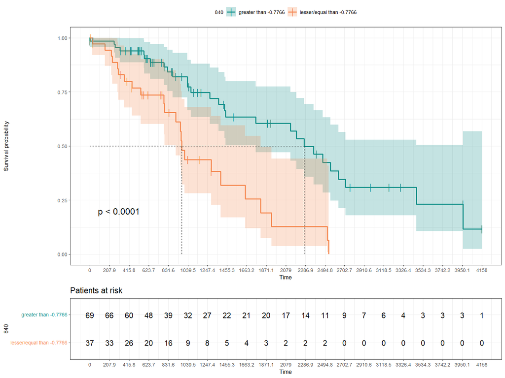

```r
LST_KM_RES_VAR$`iSB.sPLS-DRCOX`$LST_PLOTS$proteomic$`840`
```

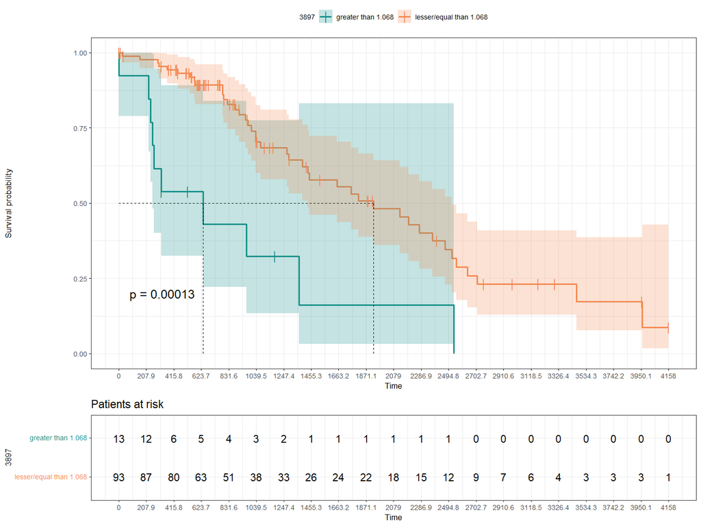

```r
LST_KM_RES_VAR$`iSB.sPLS-DRCOX`$LST_PLOTS$proteomic$`3897`
```

```r
lst_cutoff <- getCutoffAutoKM.list(LST_KM_RES_VAR)

LST_KM_TEST_VAR <- getTestKM.list(lst_models = lst_models,
                                  X_test = X_test, Y_test = Y_test,
                                  type = "VAR", ori_data = T,
                                  BREAKTIME = NULL, n.breaks = 20,
                                  lst_cutoff = lst_cutoff)
```

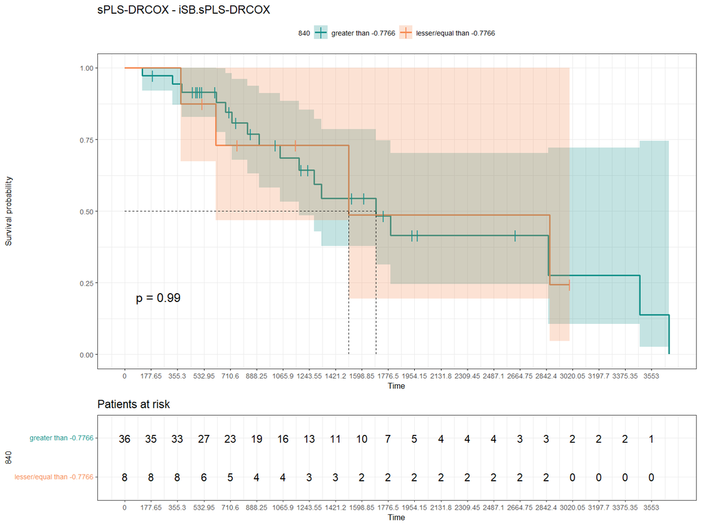

```r
LST_KM_TEST_VAR$`iSB.sPLS-DRCOX`$proteomic$`840`
```

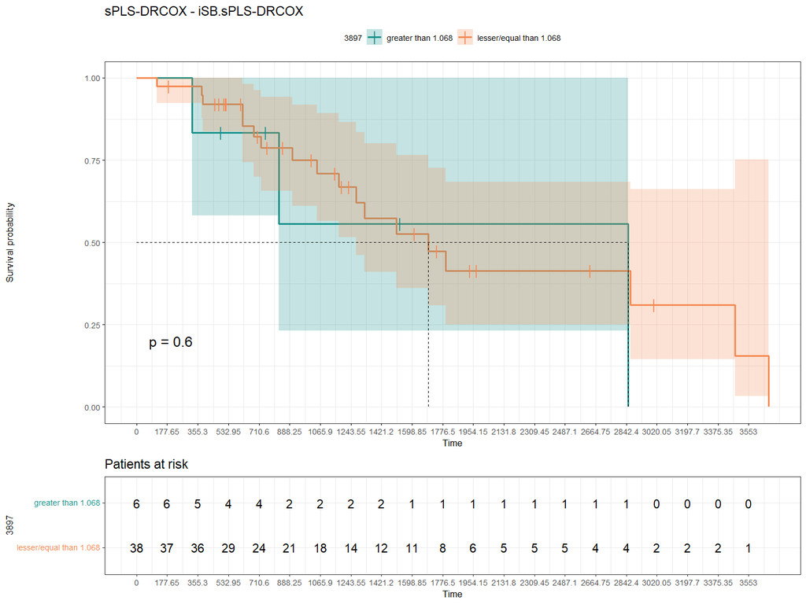

```r
LST_KM_TEST_VAR$`iSB.sPLS-DRCOX`$proteomic$`3897`
```

# New patients

In addition, HDCox can also manage new patients to perform predictions.

To demonstrate, an observation from a test dataset will be used.

```r
new_pat <- list()
for(b in names(X_test)){
  new_pat[[b]] <- X_test[[b]][1,,drop=F]
}
```

```r
knitr::kable(Y_test[rownames(new_pat$mirna),])
```

|  | time | event |
| --- | --- | --- |
| TCGA-A2-A0SV-01A | 825 | TRUE |

The function `plot_pseudobeta_newPatient.list()` or `plot_pseudobeta_newPatient()` allows the user to compare the characteristics of a new patient with the pseudo-beta values obtained from a specific model. The goal is to understand in a general way which variables are associated with an increased risk of an event or a decreased risk, in comparison to the variables predicted by the model.

```r
ggp.simulated_beta_newPat <- plot_pseudobeta_newPatient.list(lst_models = lst_models,
                                                             new_observation = new_pat,
                                                             error.bar = T, onlySig = T, alpha = 0.05,
                                                             zero.rm = T, auto.limits = T, show.betas = T, top = 20)
```

[output not shown]

```r
# ggp.simulated_beta_newPat <- plot_pseudobeta_newPatient(model = lst_models$`sPLS-DRCOX`,
#                                                         new_observation = new_pat,
#                                                         error.bar = T, onlySig = T, alpha = 0.05,
#                                                         zero.rm = T, auto.limits = T, show.betas = T, top = 20)
```

```r
ggp.simulated_beta_newPat$`iSB.sPLS-DRCOX`$plot$proteomic
```

[output not shown]

## Add patient to density plot

```r
pat_density <- plot_observation.eventDensity(patient = new_pat,
                                             model = lst_models$`iSB.sPLS-DRCOX`,
                                             time = NULL,
                                             type = "lp")
```

[output not shown]

```r
pat_density
```

[output not shown]

```r
pat_histogram <- plot_observation.eventHistogram(patient = new_pat,
                                                 model = lst_models$`iSB.sPLS-DRCOX`,
                                                 time = NULL,
                                                 type = "lp")
```

[output not shown]

```r
pat_histogram
```

[output not shown]

## COX compare patients

As an idea, this function could also be used to study the same patient in different time points after receiving a treatment and study its own evolution related to the original variables.

```r
sub_X_test <- list()
for(b in names(X_test)){
  sub_X_test[[b]] <- X_test[[b]][1:5,]
}
```

```r
knitr::kable(Y_test[rownames(sub_X_test$proteomic),])
```

|  | time | event |
| --- | --- | --- |
| TCGA-A2-A0SV-01A | 825 | TRUE |
| TCGA-A2-A0YT-01A | 723 | TRUE |
| TCGA-BH-A1FB-01A | 3669 | TRUE |
| TCGA-D8-A1XC-01A | 377 | TRUE |
| TCGA-BH-A1EX-01A | 1508 | TRUE |

To generate the figure, the function `plot_LP.multiplePatients.list()` or `plot_LP.multiplePatients()` can be used.

```r
lst_cox.comparison <- plot_LP.multiplePatients.list(lst_models = lst_models,
                                                    new_data = sub_X_test,
                                                    error.bar = T, zero.rm = T, onlySig = T,
                                                    alpha = 0.05, top = 5)
```

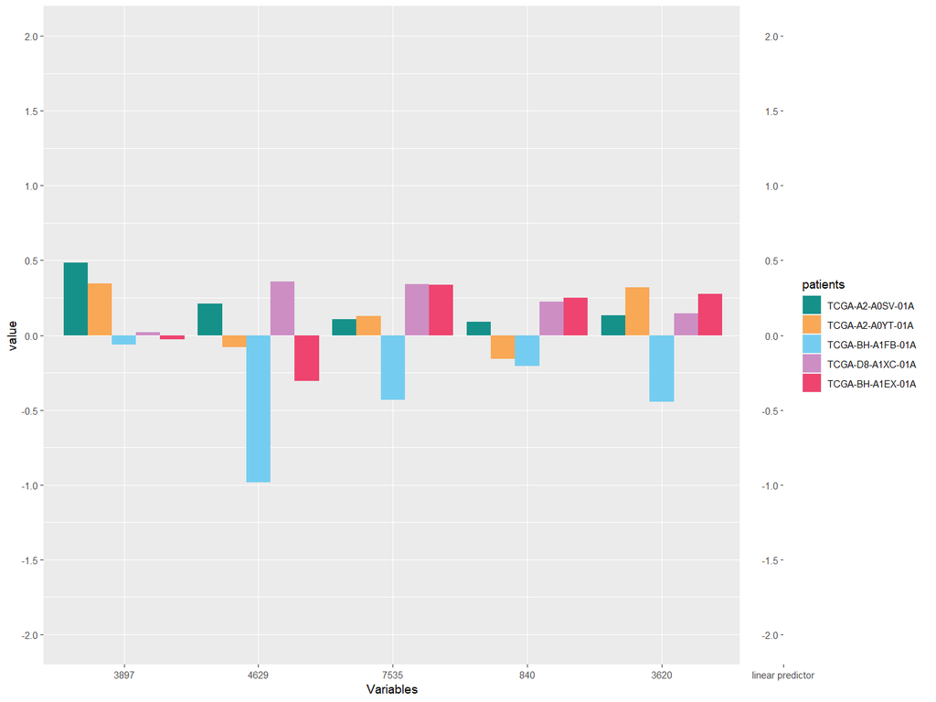

```r
lst_cox.comparison$`iSB.sPLS-DRCOX`$plot
```